# coding5

rachel

2025-02-28

```r
library(ggplot2)
library(nycflights13)
library(dplyr)
library(tidyr)
library(tibble)
```

##1 Use the dataset “mtcars”, create a bar plot showing the count of cars for each cylinders category (cyl). fill the bars with skyblue color, and add a black outline around each bar.

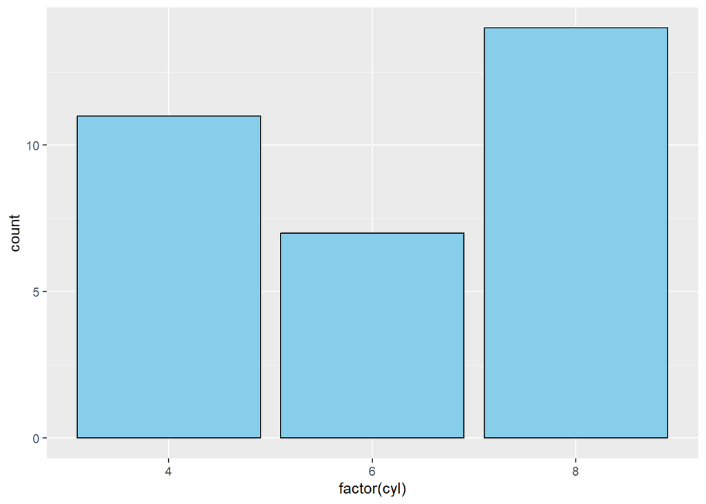

```r
ggplot(mtcars, aes(x = factor(cyl))) +
  geom_bar(fill = "skyblue", color = "black")
```

##2 Use the dataset “iris”, plot a histogram of the variable “Sepal.Length”, and set the number of bins to 20, fill the bars with pink color, and add a black outline around each bar.

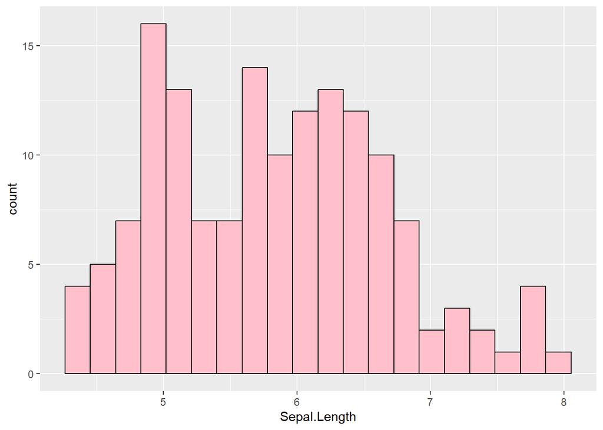

```r
ggplot(iris, aes(x = Sepal.Length)) +
  geom_histogram(bins = 20, fill = "pink", color = "black")
```

##3 Use the dataset “mtcars”, use group_by() to group the data by gear and cyl, then find the mean mpg value for each group using summarize(). Remember to remove the missing values.

```r
mean_mpg_by_group <- mtcars %>%
  group_by(gear, cyl) %>%
  summarise(mean_mpg = mean(mpg, na.rm = TRUE))
mean_mpg_by_group
```

```
## # A tibble: 8 × 3
## # Groups:   gear [3]
##    gear   cyl mean_mpg
##   <dbl> <dbl>    <dbl>
## 1     3     4     21.5
## 2     3     6     19.8
## 3     3     8     15.0
## 4     4     4     26.9
## 5     4     6     19.8
## 6     5     4     28.2
## 7     5     6     19.7
## 8     5     8     15.4
```

##4 Use the dataset “airquality”, gather “Ozone”, “Solar.R”, “Wind”, and “Temp” into two colums: “variable” (the original column name) and “value” (the corresponding value) using pivot_longer(). Save and name this dataset as “airquality_long”. Then use the head() to show its first 6 rows.

```r
airquality_long <- airquality %>%
  pivot_longer(cols = c(Ozone, Solar.R, Wind, Temp),
               names_to = "variable",
               values_to = "value")
head(airquality_long)
```

```
## # A tibble: 6 × 4
##   Month   Day variable value
##   <int> <int> <chr>    <dbl>
## 1     5     1 Ozone     41
## 2     5     1 Solar.R  190
## 3     5     1 Wind       7.4
## 4     5     1 Temp      67
## 5     5     2 Ozone     36
## 6     5     2 Solar.R  118
```

##5 Use pivot_wider() to restitute the dataset “airquality_long” (get back to what the “airquality” looks like). Then use the head() to show the first 6 rows.

```r
airquality_long <- airquality %>%
  pivot_longer(cols = c(Ozone, Solar.R, Wind, Temp),
               names_to = "variable",
               values_to = "value")
airquality_wide <- airquality_long %>%
  pivot_wider(names_from = variable, values_from = value)
head(airquality_wide)
```

```
## # A tibble: 6 × 6
##   Month   Day Ozone Solar.R  Wind  Temp
##   <int> <int> <dbl>   <dbl> <dbl> <dbl>
## 1     5     1    41     190   7.4    67
## 2     5     2    36     118   8      72
## 3     5     3    12     149  12.6    74
## 4     5     4    18     313  11.5    62
## 5     5     5    NA      NA  14.3    56
## 6     5     6    28      NA  14.9    66
```

##6 Create a tibble named students with three columns: Name (character), Age (integer), and Score (numeric). Add 5 rows of data manually.

```r
students <- tibble(
  Name = c("Alice", "Bob", "Charlie", "David", "Eva"),
  Age = c(20, 21, 19, 22, 20),
  Score = c(90, 92, 88, 93, 86)
)
students
```

```
## # A tibble: 5 × 3
##   Name      Age Score
##   <chr>   <dbl> <dbl>
## 1 Alice      20    90
## 2 Bob        21    92
## 3 Charlie    19    88
## 4 David      22    93
## 5 Eva        20    86
```

##7 Use the dataset “mtcars”. [1] Select only the columns mpg, hp, wt, and cyl. [2] Filter the data to only include cars with mpg > 20. [3] Arrange the filtered data by hp in descending order. [4] Create a scatter plot of hp vs. wt, colored by cyl.

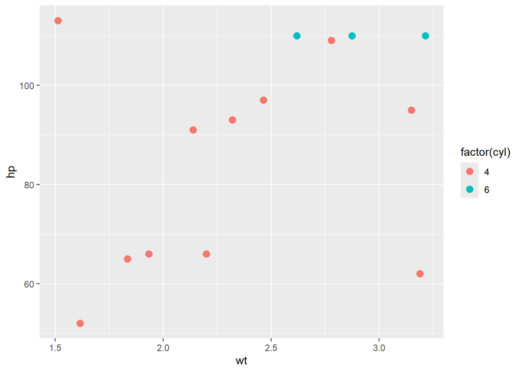

```r
selected_data <- mtcars %>% select(mpg, hp, wt, cyl)
filtered_data <- selected_data %>% filter(mpg > 20)
arranged_data <- filtered_data %>% arrange(desc(hp))
ggplot(arranged_data, aes(x = wt, y = hp, color = factor(cyl))) +
  geom_point(size = 3)
```

##8 Use the dataset “starwawrs”. [1] Filter out characters with missing mass OR height. [2] Keep only characters whose mass is greater than 100 and height is greater than 200. [3] Arrange the result by height in descending order. [4] Create a bar plot where the x-axis represents the name of characters, and the y-axis represents their height, fill each bar with “orange” color. HINT: reorder() function can be used to order X by the average value of Y when you’re creating a bar plot. For example, if you want to order name by height, you may use aes(x = reorder(name, height), y = height).

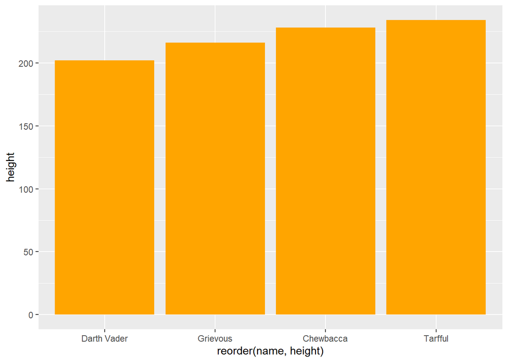

```r
filtered_data <- starwars %>% filter(!is.na(mass) & !is.na(height))
filtered_data <- filtered_data %>% filter(mass > 100 & height > 200)
arranged_data <- filtered_data %>% arrange(desc(height))
ggplot(arranged_data, aes(x = reorder(name, height), y = height)) +
  geom_bar(stat = "identity", fill = "orange")
```

##9 Use the dataset “flights”. [1] Create a new column speed (miles per hour) calculated as distance / (air_time / 60). [2] Filter for flights that traveled over 2,000 miles and had a speed greater than 500 mph. [3] Select the columns carrier, flight, origin, dest, speed, and distance. [4] Create a scatter plot where the x-axis represents speed, and the y-axis represents distance. Use carrier for color.

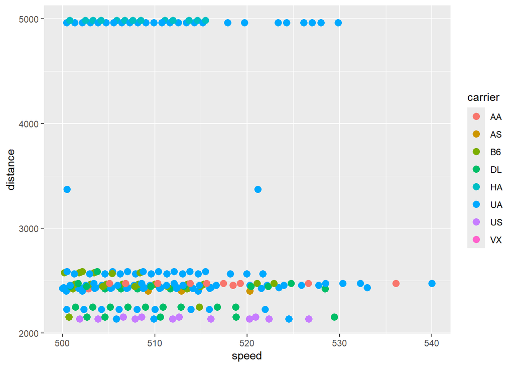

```r
flights_with_speed <- flights %>% mutate(speed = distance / (air_time / 60))
filtered_flights <- flights_with_speed %>% filter(distance > 2000 & speed > 500)
selected_flights <- filtered_flights %>% select(carrier, flight, origin, dest, speed, distance)
ggplot(selected_flights, aes(x = speed, y = distance, color = carrier)) +
  geom_point(size = 3)
```

##10 Use the dataset “diamonds”. [1] Group the dataset by cut. [2] Calculate the average price for each cut. [3] Arrange the results by average price in descending order. [4] Create a bar plot to visualize the average price for each cut and fill each cut bar different colors.

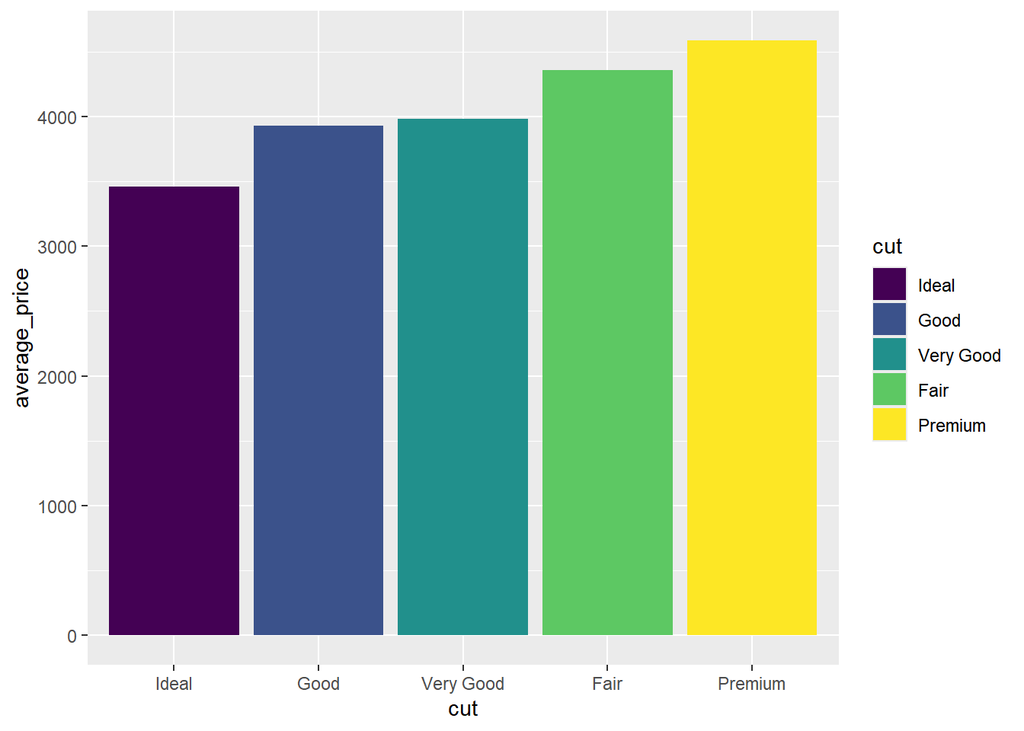

```r
average_price_by_cut <- diamonds %>% group_by(cut) %>%
  summarize(average_price = mean(price, na.rm = TRUE)) %>%
  arrange(average_price)
average_price_by_cut$cut <- factor(average_price_by_cut$cut,
                                    levels = average_price_by_cut$cut)
ggplot(average_price_by_cut, aes(x = cut, y = average_price, fill = cut)) +
  geom_bar(stat = "identity")
```